# R Notebook

You work for an animal conservation organisation and are looking to do some investigating into some of the animals to provide evidence for some projects you are looking to run.

In this homework we’ll use the msleep data set provided in the ggplot package. It concerns the sleeping patterns of various types of mammal.

Explore the dataset and familiarise yourself with it.

```r
library(tidyverse)
library(infer)
data("msleep")
```

# 1. Jabberwockies sleep for around 7 hours a night, on average. Perform an appropriate statistical test to determine whether the mean sleep_total in the sampled population of animal types differs from the typical value for jabberwockies.

H0: mu of total_sleep = 7 hours Ha: mu of total_sleep != 7 hours alpha = 0.05

# Visualise

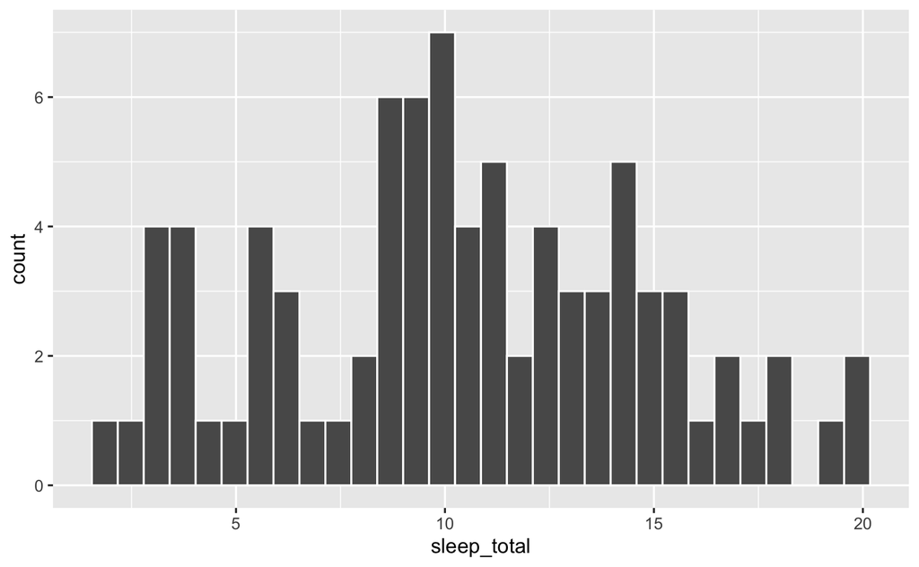

```r
msleep %>%
  ggplot() +
  aes(x = sleep_total) +
  geom_histogram(col = "white")
```

Calculate Observed Statistic

```r
mu_total_sleep <- msleep %>%
  summarise(mean_sleep = mean(sleep_total)) %>% pull(mean_sleep)
```

Generate null distribution

```r
sleep_null_dist <- msleep %>%
  specify(response = sleep_total) %>%
  hypothesise(null = "point", mu = 7) %>%
  generate(reps = 10000, type = "bootstrap") %>%
  calculate(stat = "mean")
```

Visualise Null distribution, mu and p value

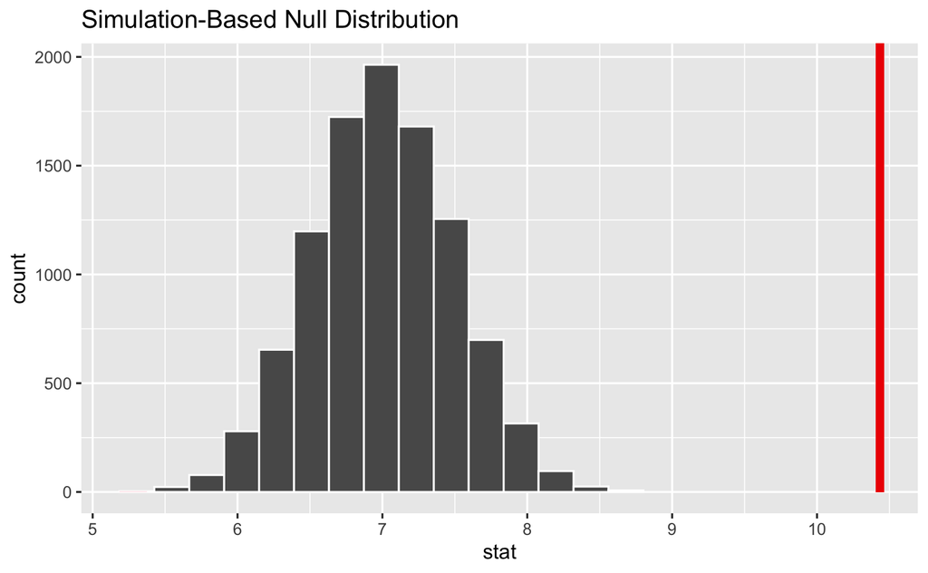

```r
sleep_null_dist %>%
  visualise() +
  shade_p_value(obs_stat = mu_total_sleep, direction = "both")
```

Calculate p value

```r
get_p_value(x = sleep_null_dist, obs_stat = mu_total_sleep, direction = "both")
```

```
Please be cautious in reporting a p-value of 0. This result is an approximation based on the number of `reps` chosen in the `generate()` step. See `?get_p_value()` for more information.
```

| p_value |
| --- |
| 0 |

## Conclusion

We have a p value of close to 0, this is less than our alpha so we decide tp reject the null hypothesis and feel confident that the average sleep for the animals in this dataset differs significantly from the average sleep value for a jabberworcky of 7 hours.

# 2. Perform an appropriate statistical test to determine whether omnivores sleep for significantly longer than herbivores, on average.

Design test H0: mu sleep_total_omni - mu_sleep_total_herbi = 0 This hypothesises that there is no relationship between sleep length and vore Ha: mu sleep_total_omni - mu_sleep_total_herbi > 0 This hypothesises that omnivores sleep for significantly longer than herbivores, as per our question alpha = 0.05

Visualise

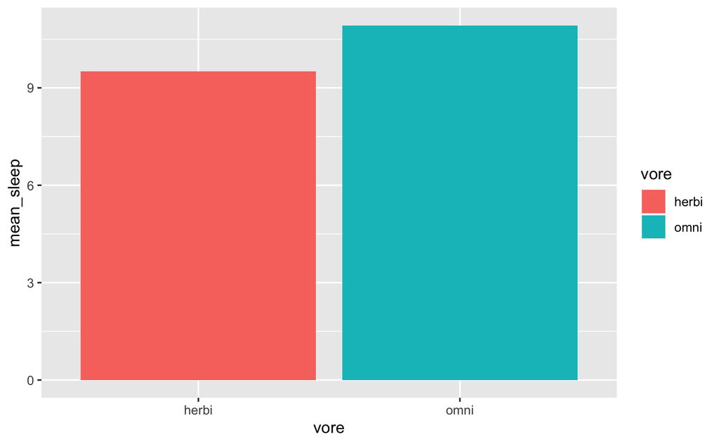

```r
vore_sleep <- msleep %>%
  filter(vore %in% c("herbi", "omni"))

vore_sleep %>%
  group_by(vore) %>%
  summarise(count = n(),
            mean_sleep = mean(sleep_total)) %>%
  ggplot() +
  aes(x = vore, y = mean_sleep, fill = vore) +
  geom_col()
```

Observed difference in means

```r
diff_means_vore <- vore_sleep %>%
  specify(response = sleep_total, explanatory = vore) %>%
  calculate(stat = "diff in means", order = c("omni", "herbi"))
```

Null distribution using shuffle

```r
vore_null_dist <- vore_sleep %>%
  specify(response = sleep_total, explanatory = vore) %>%
  hypothesise(null = "independence") %>%
  generate(reps = 10000, type = "permute") %>%
  calculate(stat = "diff in means", order = c("omni", "herbi"))
```

Visualise null distribution and observation

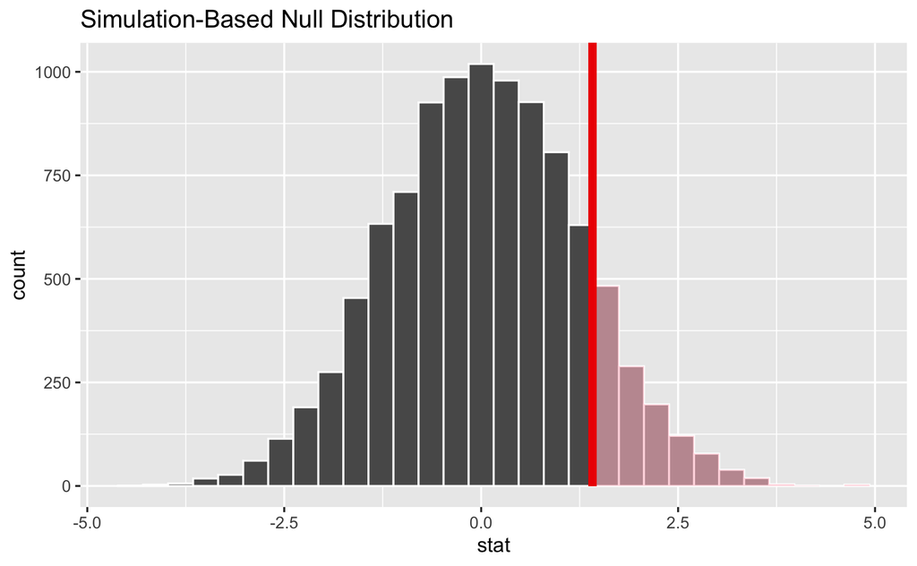

```r
vore_null_dist %>%
  visualise(bins = 30) +
  shade_p_value(obs_stat = diff_means_vore, direction = "greater")
```

Calculate p value

```r
get_p_value(vore_null_dist, obs_stat = diff_means_vore, direction = "greater")
```

| p_value |
| --- |
| 0.1258 |

Conclusion With a p value of 0.126, we fail to reject the null hypothesis, we do not have enough evidence to say that omnivores sleep for significantly longer than herbivores

# 3. Perform an appropriate statistical test to determine whether the proportion of domesticated animal types in the population of animal types is greater than 5%.

[Hint - think about creating an is_domesticated variable for the analysis]

Design test H0: proportion_domesticated_population = 0.05 Ha: proportion_domesticated_population > 0.05 alpha: 0.05

Calculate proportion of domesticated animals in sample

```r
msleep <- msleep %>%
  mutate(is_dom = if_else(
    conservation == "domesticated",
    "dom", "not_dom"
  ))

# Find number of NAs for conservation
msleep %>%
  filter(is.na(is_dom))
```

| name | genus | vore | order | conservation | sleep_total | sleep_rem | sleep_cycle | awake | brainwt | bodywt | is_dom |
| --- | --- | --- | --- | --- | --- | --- | --- | --- | --- | --- | --- |
| Owl monkey | Aotus | omni | Primates | NA | 17.0 | 1.8 | NA | 7.0 | 0.01550 | 0.480 | NA |
| Three-toed sloth | Bradypus | herbi | Pilosa | NA | 14.4 | 2.2 | 0.7666667 | 9.6 | NA | 3.850 | NA |
| Vesper mouse | Calomys | NA | Rodentia | NA | 7.0 | NA | NA | 17.0 | NA | 0.045 | NA |
| African giant pouched rat | Cricetomys | omni | Rodentia | NA | 8.3 | 2.0 | NA | 15.7 | 0.00660 | 1.000 | NA |
| Western american chipmunk | Eutamias | herbi | Rodentia | NA | 14.9 | NA | NA | 9.1 | NA | 0.071 | NA |
| Galago | Galago | omni | Primates | NA | 9.8 | 1.1 | 0.5500000 | 14.2 | 0.00500 | 0.200 | NA |
| Human | Homo | omni | Primates | NA | 8.0 | 1.9 | 1.5000000 | 16.0 | 1.32000 | 62.000 | NA |
| Macaque | Macaca | omni | Primates | NA | 10.1 | 1.2 | 0.7500000 | 13.9 | 0.17900 | 6.800 | NA |
| Vole | Microtus | herbi | Rodentia | NA | 12.8 | NA | NA | 11.2 | NA | 0.035 | NA |
| Little brown bat | Myotis | insecti | Chiroptera | NA | 19.9 | 2.0 | 0.2000000 | 4.1 | 0.00025 | 0.010 | NA |

[output cut: 19 more lines]

```r
# 29 of 83 rows

msleep %>%
  filter(!is.na(is_dom)) %>%
  specify(response = is_dom, success = "dom") %>%
  calculate(stat = "prop")
```

| stat |
| --- |
| 0.1851852 |

Generate null distribution for H0

```r
null_dist_prop_animals <- msleep %>%
  specify(response = is_dom, success = "dom") %>%
  hypothesise(null = "point", p = 0.05) %>%
  generate(reps = 5000, type = "simulate") %>%
  calculate(stat = "prop")
```

```
Removed 29 rows containing missing values.
```

Visualise null distribution, observed stat and p value

[figure not shown]

Get p value

```r
get_p_value(x = null_dist_prop_animals, obs_stat = sample_prop_dom, direction = "greater")
```

```
Please be cautious in reporting a p-value of 0. This result is an approximation based on the number of `reps` chosen in the `generate()` step. See `?get_p_value()` for more information.
```

| p_value |
| --- |
| 0 |

Conclusions We get a p value of close to 0, which allows us to reject the null hypothesis and infer that the percentage of domesticated animals in the population is greater than 5%